# Machine Learning Course Project

Arthur Conner

May 21, 2015

### Overview:

In this project we are going to analyze the sensor data to what activtiy level seems to be done.

### the model

```r
library(ggplot2)
library(caret)
#load the data
trainFull <-read.csv("pml-training.csv",sep=",",header=TRUE)

allCol = c("roll_belt", "pitch_belt", "yaw_belt", "total_accel_belt", "gyros_belt_x", "gyros_belt_y", "gyros_belt_z", "accel_belt_x", "accel_belt_y", "accel_belt_z", "magnet_belt_x", "magnet_belt_y", "magnet_belt_z", "roll_arm", "pitch_arm", "yaw_arm", "total_accel_arm", "gyros_arm_x", "gyros_arm_y", "gyros_arm_z", "accel_arm_x", "accel_arm_y", "accel_arm_z", "magnet_arm_x", "magnet_arm_y", "magnet_arm_z", "roll_dumbbell", "pitch_dumbbell", "yaw_dumbbell", "total_accel_dumbbell", "gyros_dumbbell_x", "gyros_dumbbell_y", "gyros_dumbbell_z", "accel_dumbbell_x", "accel_dumbbell_y", "accel_dumbbell_z", "magnet_dumbbell_x", "magnet_dumbbell_y", "magnet_dumbbell_z", "roll_forearm", "pitch_forearm", "yaw_forearm", "total_accel_forearm", "gyros_forearm_x", "gyros_forearm_y", "gyros_forearm_z", "accel_forearm_x", "accel_forearm_y", "accel_forearm_z", "magnet_forearm_x", "magnet_forearm_y", "magnet_forearm_z","classe")

#partition the data so we can validate it later
trainPartial = trainFull[,allCol]
inTrain <- createDataPartition(y=trainPartial$classe,
p=0.7, list=FALSE)
training <- trainPartial[inTrain,]
testing <- trainPartial[-inTrain,]

write.table(training,file="partialTrain.csv",sep=",",col.names=TRUE)
write.table(training,file="partialTest.csv",sep=",",col.names=TRUE)
```

### Models

random forrests tend to be the best thing if you haven’t worked the dataset over. During one of the video lectures it was mentioned that these and boost are used to win kaggle competions

### Using caret

I think my issue was using category columns. This *should* work with random forrests, but the results that came back were bad - there were all kinds of esocteric error messages. I did look inside the testing file to see which columns weren’t NA and used only those columns to create the model.

### a Decision model

I first wanted to test using a single decision tree since this would be relatively quick to calculate.

From this we can ge the feature importance.

```r
library(ggplot2)
library(caret)

descFit <- train(classe ~ .,method="rpart",data=training)
varImp(descFit)
```

```
## rpart variable importance
##
##   only 20 most important variables shown (out of 52)
##
##                   Overall
## pitch_forearm      100.00
## roll_forearm        67.79
## roll_belt           67.43
## magnet_dumbbell_y   46.84
## accel_belt_z        41.73
## magnet_belt_y       40.42
## yaw_belt            39.11
## total_accel_belt    34.90
## magnet_arm_x        26.57
## accel_arm_x         26.27
## roll_dumbbell       18.30
## magnet_dumbbell_x   18.03
## magnet_dumbbell_z   17.60
## roll_arm            15.76
## accel_dumbbell_y    14.45
## magnet_arm_y         0.00
## magnet_belt_z        0.00
## accel_dumbbell_z     0.00
## accel_arm_y          0.00
## gyros_forearm_z      0.00
```

```r
pred <- predict(descFit,testing); testing$predRight <- pred==testing$classe
table(pred,testing$classe)
```

```
##
## pred    A    B    C    D    E
##    A 1545  476  463  444  158
##    B   19  394   34  156  144
##    C  106  269  529  364  277
##    D    0    0    0    0    0
##    E    4    0    0    0  503
```

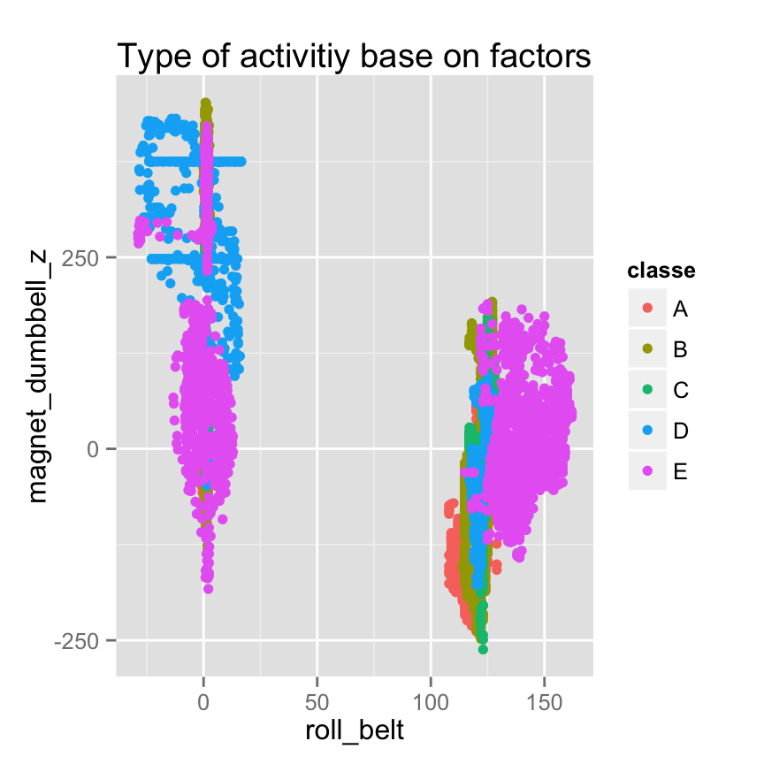

```r
qplot(data=training,x=roll_belt,y=magnet_dumbbell_z,color=classe,main="Type of activitiy base on factors")
```

```r
modelFileName = "randomforest5.rda"

if(file.exists(modelFileName)) {
    ## load model
    load(modelFileName)
} else {
    ## (re)fit the model
  #this took a long time to run using the defaults

  #   user   system  elapsed
#6305.859   21.287 6345.707

  #with number 2
  #  user  system elapsed
#334.274   2.688 339.576
  fitControl <- trainControl(method = "boot",
             number = 3,
             repeats = 1,
             p = 0.75,
             verboseIter = TRUE
)

 system.time(modelFit <- train(classe ~.,data=training,method="rf",trControl = fitControl,verbose = TRUE))
 save(modelFit,file =modelFileName)

}
varImp(modelFit)
```

```
## rf variable importance
##
##   only 20 most important variables shown (out of 52)
##
##                   Overall
## roll_belt          100.00
## yaw_belt            78.51
## magnet_dumbbell_z   68.46
## pitch_belt          62.28
## pitch_forearm       62.05
## magnet_dumbbell_y   61.08
## magnet_dumbbell_x   51.23
## roll_forearm        50.90
## accel_belt_z        46.20
## accel_dumbbell_y    44.62
## magnet_belt_y       43.44
## magnet_belt_z       42.80
## roll_dumbbell       41.27
## accel_dumbbell_z    36.78
## roll_arm            31.03
## accel_forearm_x     30.29
## gyros_belt_z        29.50
## yaw_dumbbell        28.84
## accel_dumbbell_x    28.09
## magnet_arm_y        27.55
```

### Comparing Errors

We can now look at a single decistion tree versus the random forest to get a sense of how they did

```r
prediction <- predict(modelFit, testing)
missClass = function(values, prediction) {
    sum(prediction != values)/length(values)
}
errRate = missClass(testing$classe, prediction)
errRate
```

```
## [1] 0.002039082
```

```r
prediction <- predict(descFit, testing)
errRate = missClass(testing$classe, prediction)
errRate
```

```
## [1] 0.4951572
```

The error rate of the random forrest is signifantly better than the one for the single decision tree.